# Modelling Average Electricity Demand in Great Britain

Ella Park (s2311400), Rosie Crookes (s2333530), Kieran Marguerie de Rotrou (s2536961)

#### Word count: 1092

# Executive Summary

The aim of this study is to predict average daily electricity demand to enable NESO to ensure a reliable supply. Forecasting is performed using an ordinary least squares linear regression model. This is selected by identifying key temporal and weather based predictors as well as considering important metrics such as $R^2$ and AIC. The model is then evaluated for it’s practicality and predictive ability using cross validation. We ultimately conclude, the model predicts average demand accurately while remaining simple and practical.

# Data Analysis and Exploration

Prior to fitting models we examine the dataset used in our analysis. We consider the following predictor variables for our linear model:

- $\texttt{wind_merra}$: Average capacity factor of wind generation
- $\texttt{solar_sarah}$: Average capacity factor of solar generation
- $\texttt{temp_merra1}$: Average temperature
- $\texttt{wdayindex}$: Day of the week - included as a factor variable
- $\texttt{month}$: Month - included as a factor variable
- $\texttt{year}$: Year - included as a factor variable. However, this will be stripped out of the model by NESO, who will add their own year effect for future years.
- $\texttt{DSN}$: Number of days since November
- $\texttt{TO}$: Average temperature from 3 PM – 6 PM on each day
- $\texttt{TE}$: Average of $\texttt{TO}$ at 6 PM and $\texttt{TE}$ at 6 PM on the previous day ($\texttt{TE}$ for 1 November 1991 taken as 11.37 degrees celsius).

Figures and observations from our data exploration are recorded below.

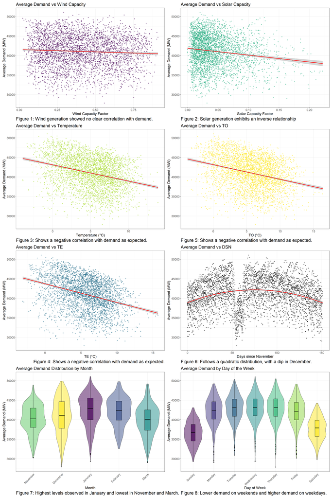

# Model Selection and Evaluation

We fit an ordinary least-squares linear regression model:
$$\mathbf{y} = X \boldsymbol{\beta} +
\boldsymbol{\epsilon}$$
assuming

- Linearity of model parameters.
- Errors, $\boldsymbol{\epsilon}$, are normally distributed.
- Errors are independent.
- Errors have constant variance (homoscedasticity).

## Metrics

Variable significance is assessed through hypothesis testing model parameters, where a high p-value indicates no statistically significant effect in the model. The $R^2$ metric measures the proportion of variance explained. Models with a higher adjusted $R^2$ are generally preferred, as this indicates that the model explains a higher proportion of the variability within the data. Predictive accuracy is assessed through root mean squared error (RMSE). It measures the average magnitude of the residuals, with lower values indicating that the model’s predictions are closer to the observed data. The AIC is used to balance model fit with complexity by penalising the number of parameters included in the model. A model with lower AIC is preferred, as it explains the data well without including unnecessary parameters.

## Model selection

Based on the exploratory analysis, the final model was selected to capture key predictors and account for non-linearities and interactions while balancing simplicity:

$$\begin{eqnarray*}
M_F: y_i = \beta_0 + \beta_1 \text{solar}_i + \beta_2
\text{wdaynumber}_i + \beta_3 \text{month}_i + \beta_4 \text{year}_i +
\beta_5 \text{DSN}^2_i + \beta_6 \text{TE}_i + \beta_7 \,
\text{DSN}^2\text{:month}_i + \epsilon_i
\end{eqnarray*}$$
where $\epsilon_i \overset{\mathrm{iid}}\sim \mathcal{N}(0, \sigma^2)$.

The `TE` variable was selected as the temperature measure because it incorporates both the current and previous day information, capturing lagged effects. Models using `TE` produced a higher $R^2$, lower RMSE and lower AIC indicating a better overall model fit and predictive performance. The `DSN` variable exhibited a quadratic relationship with demand, so $DSN^2$ was included. `Month` and `Year` were included as factor variables to account for annual variation. A distinct dip in demand in December motivated the inclusion of an interaction between `DSN^2` and `Month`, allowing the model to capture monthly variations in the quadratic effect and substantially improving the AIC by 1,846.95.

Table 1: Model Performance Comparison

| Model | $R^2$ | Adjusted $R^2$ | RMSE | AIC |
| --- | --- | --- | --- | --- |
| Model with temp | 0.8585733 | 0.8569565 | 1533.105 | 62062.24 |
| Model with TO | 0.8478952 | 0.8461564 | 1589.928 | 62319.91 |
| Model with TE | 0.8696681 | 0.8681782 | 1471.741 | 61773.03 |

The remaining variables were included due to trends seen in exploratory analysis and as they are statistically significant, mostly with $p<0.01$.

Table 2: Regression Results

|  | Estimate | Std. Error | t value | Pr(>\|t\|) |
| --- | --- | --- | --- | --- |
| (Intercept) | 33526.962 | 321.157 | 104.394 | 0.000 |
| TE | -529.501 | 10.654 | -49.700 | 0.000 |
| solar_sarah | -15846.613 | 1141.001 | -13.888 | 0.000 |
| factor(WeekdayNum)1 | 5596.396 | 93.053 | 60.142 | 0.000 |
| factor(WeekdayNum)2 | 6324.780 | 93.121 | 67.920 | 0.000 |
| factor(WeekdayNum)3 | 6360.136 | 93.097 | 68.317 | 0.000 |
| factor(WeekdayNum)4 | 6279.360 | 93.250 | 67.339 | 0.000 |
| factor(WeekdayNum)5 | 5464.630 | 93.218 | 58.622 | 0.000 |
| factor(WeekdayNum)6 | 1169.326 | 93.079 | 12.563 | 0.000 |
| I(DSN^2) | 0.660 | 0.041 | 16.114 | 0.000 |
| factor(Month)2 | 4825.442 | 455.153 | 10.602 | 0.000 |
| factor(Month)3 | 5306.641 | 496.149 | 10.696 | 0.000 |
| factor(Month)11 | 3286.746 | 266.867 | 12.316 | 0.000 |
| factor(Month)12 | 9149.686 | 289.650 | 31.589 | 0.000 |
| factor(Year)1992 | -34.595 | 226.488 | -0.153 | 0.879 |
| factor(Year)1993 | -26.648 | 226.925 | -0.117 | 0.907 |
| factor(Year)1994 | 453.790 | 227.098 | 1.998 | 0.046 |
| factor(Year)1995 | 1502.790 | 226.743 | 6.628 | 0.000 |
| factor(Year)1996 | 2365.578 | 227.285 | 10.408 | 0.000 |
| factor(Year)1997 | 2804.758 | 227.065 | 12.352 | 0.000 |
| factor(Year)1998 | 3134.583 | 227.123 | 13.801 | 0.000 |
| factor(Year)1999 | 3779.208 | 226.878 | 16.657 | 0.000 |
| factor(Year)2000 | 4435.593 | 226.786 | 19.558 | 0.000 |
| factor(Year)2001 | 5206.297 | 226.702 | 22.965 | 0.000 |
| factor(Year)2002 | 5574.093 | 227.401 | 24.512 | 0.000 |
| factor(Year)2003 | 6347.567 | 226.968 | 27.967 | 0.000 |
| factor(Year)2004 | 6576.452 | 226.678 | 29.012 | 0.000 |
| factor(Year)2005 | 5704.218 | 226.901 | 25.140 | 0.000 |
| factor(Year)2006 | 5376.686 | 226.954 | 23.691 | 0.000 |
| factor(Year)2007 | 4761.861 | 227.234 | 20.956 | 0.000 |
| factor(Year)2008 | 4100.558 | 226.620 | 18.094 | 0.000 |
| factor(Year)2009 | 2600.179 | 226.727 | 11.468 | 0.000 |
| factor(Year)2010 | 2864.807 | 228.077 | 12.561 | 0.000 |
| factor(Year)2011 | 2258.601 | 227.157 | 9.943 | 0.000 |
| factor(Year)2012 | 1629.380 | 226.662 | 7.189 | 0.000 |
| factor(Year)2013 | 1119.108 | 227.056 | 4.929 | 0.000 |
| factor(Year)2014 | 488.905 | 227.196 | 2.152 | 0.031 |
| I(DSN^2):factor(Month)2 | -0.708 | 0.053 | -13.357 | 0.000 |
| I(DSN^2):factor(Month)3 | -0.728 | 0.047 | -15.418 | 0.000 |
| I(DSN^2):factor(Month)11 | 0.502 | 0.225 | 2.231 | 0.026 |
| I(DSN^2):factor(Month)12 | -3.808 | 0.079 | -48.028 | 0.000 |

## Model Evaluation

The residuals were examined to check the underlying assumptions are satisfied, ensuring the model provides a valid fit to the data.

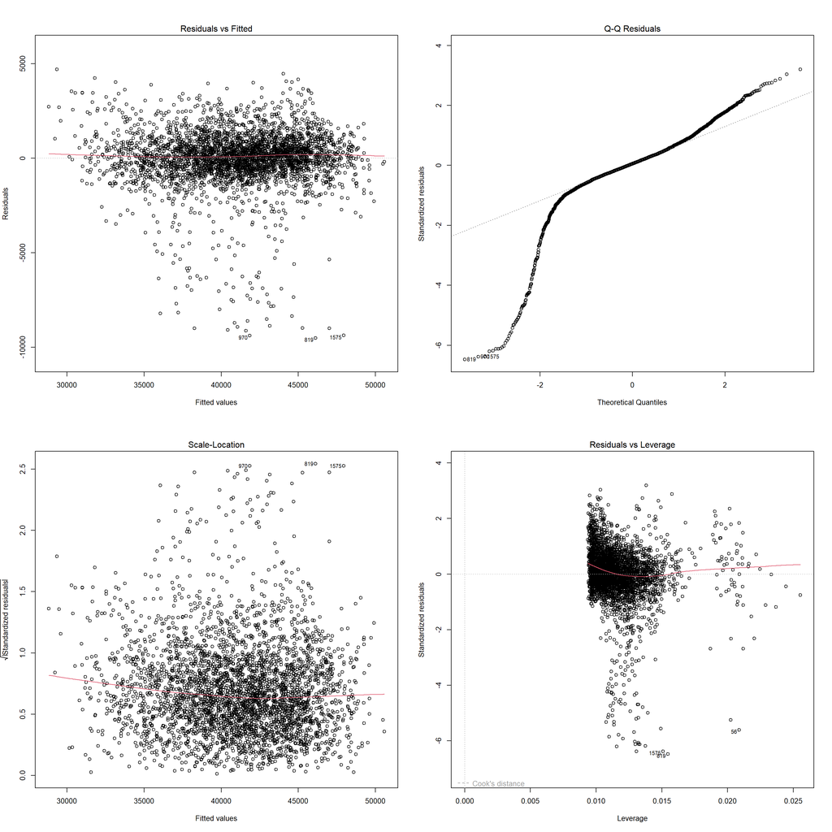

# Cross Validation:

## Methodology

To assess model generalizability, we used expanding window cross-validation. Since, our model includes year as a factor, which would be updated by NESO annually based on their estimated year effect, we altered our cross validation method as follows:

Firstly we fit the model on an initial training set from 1991 up to 2000. Then the year effect is removed from the trained model. Using this, we compute the ‘yearless predictions’ for 2001. To mimic adding back in a year effect we assumed a known year effect, using the coefficient estimated from the full dataset. This was added to the ‘yearless predictions’ to compute our final predictions. We then compare these with the observed data for 2001 and obtain the following metrics:

- Squared error: $\text{SE} = (y - \hat{y}_F)^2$
- Interval score: $\text{IS}(\alpha) = U_F - L_F + \frac{2}{\alpha} (L_F - y) \mathcal{1}\{y \leq L_F\} + \frac{2}{\alpha} (y - U_F) \mathcal{1}\{y > L_F\}$ where $L_F$ and $U_F$ denote the lower and upper bound of the prediction interval with coverage probability $\alpha$.
- Dawid-Sebastiani: $\text{DS} = \frac{(y - \hat{y}_F)^2}{\sigma^2_F} + \log(\sigma^2_F)$

We then repeat this process, expanding the training set by one year and moving the test set forward one year.

## Predictive Ability and Simplicity

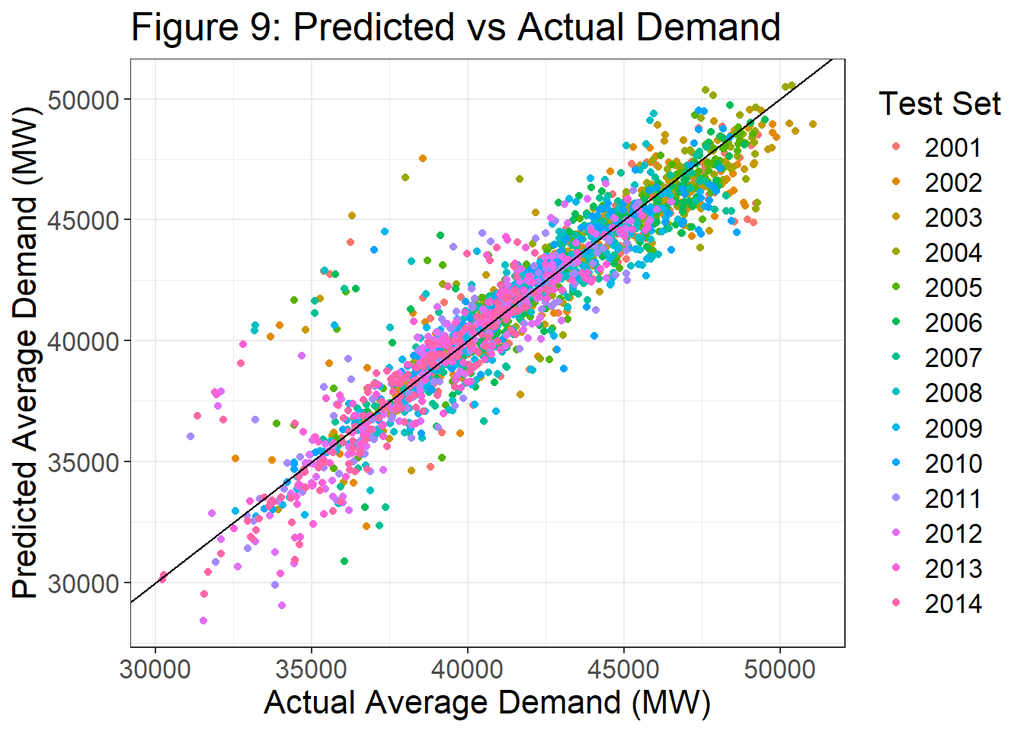

Table 3 presents the predictive scores from the cross validation for our final model and both a basic model,

$$M_B: y_i = \beta_0 + \beta_1 \text{solar}_i + \beta_2
\text{wdaynumber}_i + \beta_3 \text{month}_i + \beta_4 \text{year}_i +
\beta_5 \text{wind}_i + \beta_6 \text{temp}_i + \epsilon_i$$

and a more complex model,

$$M_C: y_i = \beta_0 + \beta_1 \text{solar}_i + \beta_2
\text{wdaynumber}_i + \beta_3 \text{month}_i + \beta_4 \text{year}_i +
\beta_5 \text{DSN}^2_i + \beta_6 \text{TE}_i + \\ \beta_7
\text{TE:solar}_i + \beta_7 \text{TE:month}_i + \beta_8
\text{solar:month}_i + \beta_9 \text{wdaynumber:month}_i + \beta_9
\text{DSN}^2\text{:month}_i + \epsilon_i$$
where $\epsilon_i \overset{\mathrm{iid}}\sim \mathcal{N}(0, \sigma^2)$.

Table 3: Predictive Scores for Final, Baseline & Complex Model

| Model | RMSE | Mean Dawid Sebastiani Score | Mean Interval Score |
| --- | --- | --- | --- |
| $M_F$ | 1462.544 | 15.58537 | 9085.693 |
| $M_{B}$ | 1872.626 | 16.09661 | 12492.786 |
| $M_{C}$ | 1449.466 | 15.56648 | 8948.997 |

Each predictive score for the final model is lower for $M_F$ than $M_B$, suggesting higher accuracy in predictions as well as confidence associated with these predictions. However, the more complex model $M_C$ achieves only marginally better scores, suggesting that a simpler, more practical model is preferable.

To see that the final model is not overfitting, observe that the fitted RMSE based on the full dataset, is greater than the Cross Validation RMSE.

Table 4: How the model performs on trained data vs new data

| Fitted RMSE | Cross Validation RMSE |
| --- | --- |
| 1471.741 | 1462.544 |

This is unusual however could be explained due to the averaging over the 14 test sets. Also note the difference is minor relative to the scale of the data, indicating that the model performs consistently on both training and new data.

# Limitations

Next consider limitations to our method and model:

By assuming the known year effect from the full model, we leak information about the test year into the predictions. We still choose this method for two reasons: firstly, it still minimises the disruption to the chronological structure of the data. Secondly, expanding the training set at each step, incorporates more historical data helping the model capture long-term, recurring monthly and weekly trends more effectively.

Secondly consider the observed vs predicted values from our cross validation in Figure 9. While the points lie scattered around the $y=x$ line indicating accurate predictions, a few points lie above the line. However these occur at lower demand levels and since NESO prioritises accuracy at higher demand levels where shortfalls are more likely to occur, the model remains well-suited for its purpose.

```r
# ---------------------------------- Packages ---------------------------------


packages <- c("ggplot2", "ecostats", "tidyverse", "patchwork", "caret",
              "gridExtra", "viridis", "rsample", "dplyr", "knitr", "kableExtra")
lapply(packages, library, character.only = TRUE)

# Read excel data files into R
original.data <- read_csv("20161213_uk_wind_solar_demand_temperature_SCS2.csv")
data <- read_csv("20161213_uk_wind_solar_demand_temperature_SCS2.csv")


# ---------------------------- Data Preprocessing ------------------------------

# Extract month, week, year, etc. from Local_DateTime column
data <- data %>%
  mutate(
    Local_DateTime = dmy_hm(`Local Time`), # Convert to POSIXct datetime object
    Month = month(Local_DateTime),
    WeekdayNum = wday(Local_DateTime) - 1,
    Year = year(Local_DateTime),
    Date = as.Date(Local_DateTime),
    Hour = hour(Local_DateTime),
    winter_year = ifelse(Month >= 11, Year, Year - 1),
    winter_start = as.Date(paste0(winter_year, "-11-01")),
    DSN = as.numeric(Date - winter_start)
  )

# TO calculation
TO_data <- data %>%
  filter(Hour >= 15 & Hour <= 18) %>% # Avg temp between 3pm and 6pm
  group_by(Date) %>%
  summarise(TO = mean(temp_merra1, na.rm = TRUE)) %>%
  ungroup() %>%
  arrange(Date)

# TE calculation
TE_data <- TO_data %>%
  mutate(TE = NA_real_)

# Initial condition: 1 Nov 1991 = 11.37 °C
TE_data$TE[1] <- 11.37

# Compute recursively
for (i in 2:nrow(TE_data)) {
  TE_data$TE[i] <- mean(c(TE_data$TO[i], TE_data$TE[i-1]), na.rm = TRUE)
}

# Join TO and TE back into main dataset
data <- data %>%
  select(-Hour) %>%
  left_join(TE_data, by = "Date")

# Restrict the dates and convert the predictor variable to average daily demand

# Define the months you want to keep
selected_months <- c(11, 12, 1, 2, 3)

# Filter for dates between 1 November and 31 March and remove the data from 2015
data <- data[data$Month %in% selected_months & data$Year != 2015, ]


# Average over the day
processed.data <- data %>%
  group_by(Date) %>%
  summarise(
    across(where(is.numeric), mean, na.rm = TRUE)
  ) %>%
  ungroup()

# -------------------------- Define Model & Formula  ---------------------------

m.final <- lm(demand_gross ~ TE + solar_sarah + factor(WeekdayNum) + I(DSN^2) +
                factor(Month) + factor(Year) + I(DSN^2):factor(Month),
              data = processed.data)

formula.final <- formula(m.final)

m.temp <- lm(demand_gross ~ temp_merra1 + solar_sarah + factor(WeekdayNum) + I(DSN^2) +
               factor(Month) + factor(Year) + I(DSN^2):factor(Month),
             data = processed.data)

m.to <- lm(demand_gross ~ TO + solar_sarah + factor(WeekdayNum) + I(DSN^2) +
             factor(Month) + factor(Year) + I(DSN^2):factor(Month),
           data = processed.data)
#--------------------------- Define Model & Formula ----------------------------

m.interactions <- step(lm(demand_gross ~ (TE + solar_sarah + factor(WeekdayNum) + I(DSN^2) + factor(Month))^2 + factor(Year), data = processed.data), direction = "backward")

m.no_interactions <- lm(demand_gross ~ TE + solar_sarah + factor(WeekdayNum) + I(DSN^2) + factor(Month) + factor(Year), data = processed.data)

# -------------------------- Define Model & Formula  ---------------------------

m.final <- lm(demand_gross ~ TE + solar_sarah + factor(WeekdayNum) + I(DSN^2) +
                factor(Month) + factor(Year) + I(DSN^2):factor(Month),
              data = processed.data)

formula.final <- formula(m.final)

# ------------------------ Computing model scores ------------------------------

comparison <- function(formulas, names, data){

  # Initialise a dataframe for the results
  results <- data.frame(
    Model = character(),
    R_squared = numeric(),
    Adjusted_R_squared = numeric(),
    RMSE = numeric(),
    AIC = numeric(),
    stringsAsFactors = FALSE
  )

  # Loop over the models
  for (i in 1:length(formulas)) {

    # Extract models and names from the inputted dataframe
    model <- lm(formulas[[i]], data)
    model_name <- names[i]

    # Calculate R-squared and Adjusted R-squared
    model_summary <- summary(model)
    r_squared <- model_summary$r.squared
    adj_r_squared <- model_summary$adj.r.squared

    # Calculate RMSE (Root Mean Squared Error)
    predictions <- predict(model, newdata = data)
    mse <- mean((data[["demand_gross"]] - predictions)^2)
    rmse <- sqrt(mse)

    # Calculate AIC
    aic_value <- AIC(model)

    # Append the results to the data frame
    results <- rbind(results, data.frame(
      Model = model_name,
      R_squared = r_squared,
      Adjusted_R_squared = adj_r_squared,
      RMSE = rmse,
      AIC = aic_value
    ))
  }
  # Return the comparison data frame
  return(results)
}


compute_scores <- function(formula, data){

  # Extract models and names from the inputted dataframe
  model <- lm(formula, data)

  # Calculate R-squared and Adjusted R-squared
  model_summary <- summary(model)
  r_squared <- model_summary$r.squared
  adj_r_squared <- model_summary$adj.r.squared

  # Calculate RMSE (Root Mean Squared Error)
  predictions <- predict(model, newdata = data)
  mse <- mean((data[["demand_gross"]] - predictions)^2)
  rmse <- sqrt(mse)

  # Append the results to the data frame
  results <- data.frame(
    R_squared = r_squared,
    Adjusted_R_squared = adj_r_squared,
    RMSE = rmse)


  # Return the comparison data frame
  return(results)
}

scores.final <- compute_scores(formula.final, processed.data)


# --------------------------- Add in year effect -------------------------------

rolling.cv <- function(formula, data, start.year, end.year, year_col, alpha){

  scores <- data.frame()

  for(year in start.year:(end.year-1)){


    # Set training and test data
    train.data <- data %>% filter(Year <= as.character(year))
    test.data <- data %>% filter(Year == as.character(year + 1))

    if(nrow(test.data) == 0) {
      message(paste("No test data for year", year + 1))
      next
    }

    # Compute Model and Prediction
    train.model  <- lm(formula, data = train.data)


    # Take out year effect from the trained model's matrix
    terms <- attr(terms(train.model), "term.labels")
    new_terms <- terms[terms != "factor(Year)"]
    new_formula <- reformulate(new_terms, response = "demand_gross")
    X.noyear <- model.matrix(new_formula, data = test.data)

    # Take out year coefficient from the trained model
    coefs <- coef(train.model)
    coefs.noyear <- coefs[!grepl("factor\\(Year\\)", names(coefs))]
    pred.noyear <- X.noyear %*% coefs.noyear

    # Extract all coefficients from the full model
    coefs.full <- coef(m.final)

    # Extract the coefficient for the test year from the full model
    year.effect <- coefs.full[paste0("factor(Year)", year + 1)]


    # Compute predictions & observed values
    pred.mean <- pred.noyear + year.effect
    obs <- test.data$demand_gross

    # Compute prediction standard deviation
    vcov.noyear <- vcov(train.model)[names(coefs.noyear), names(coefs.noyear)] # Variance Covariance matrix for the coefficients (without year)
    var.mean <- rowSums((X.noyear %*% vcov.noyear) * X.noyear) # Variance of predicted mean values
    var.residual <- sigma(train.model)^2 # Variance of model errors
    pred.sd <- sqrt(var.mean + var.residual)

    # Compute prediction interval
    pred.lwr <- pred.mean - qnorm(1 - alpha / 2) * pred.sd
    pred.upr <- pred.mean + qnorm(1 - alpha / 2) * pred.sd

    # Store predictions in a dataframe
    store.pred <- data.frame(
      observed = obs,
      predictions = pred.noyear + year.effect,
      test_set = year + 1,
      se = (obs - pred.mean)^2,
      int = pred.upr - pred.lwr + 2/(alpha) * ((pred.lwr - obs) *
                                                 (obs < pred.lwr) + (obs - pred.upr) * (obs > pred.upr)),
      ds = ((obs - pred.mean) / pred.sd)^2 + 2 * log(pred.sd)
    )


    # Store in data-frame
    scores <- rbind(scores, store.pred)

  }
  return(scores)
}

# Apply cross validation to final model
crossvalid.final <- rolling.cv(formula = formula.final, data = processed.data, start.year = 2000, end.year = 2014, alpha = 0.05)

# Summarise cross validation scores for final model
cv.scores.final <- crossvalid.final %>%

  group_by(test_set) %>%

  summarise(rmse = sqrt(mean(se)), avg.ds = mean(ds), avg.int = mean(int)) %>% # Mean per fold

  summarise(RMSE = mean(rmse), MDS = mean(avg.ds), MIS = mean(avg.int))


# ---------------------- Cross Validation on other models ----------------------

# Baseline model for comparison
m1 <-  lm(demand_gross ~
            temp_merra1 + wind_merra1 + solar_sarah + factor(WeekdayNum) +
            factor(Month) + factor(Year), data = processed.data)

# Apply cross validation to baseline model
crossvalid.m1 <- rolling.cv(formula = formula(m1), data = processed.data, start.year = 2000, end.year = 2014, alpha = 0.05)

# Summarise cross validation scores for baseline model
cv.scores.m1 <- crossvalid.m1 %>%

  group_by(test_set) %>%

  summarise(rmse = sqrt(mean(se)), avg.ds = mean(ds), avg.int = mean(int)) %>% # Mean per fold

  summarise(RMSE = mean(rmse), MDS = mean(avg.ds), MIS = mean(avg.int))


# More complex model for comparison
m2 <-  step(lm(demand_gross ~
                 (TE + solar_sarah + factor(WeekdayNum) + I(DSN^2) +
                    factor(Month))^2 + factor(Year), data = processed.data),
            direction = "backward")


# Apply cross validation to more complex model
crossvalid.m2 <- rolling.cv(formula = formula(m2), data = processed.data, start.year = 2000, end.year = 2014, alpha = 0.05)

# Summarise cross validation scores for more complex model
cv.scores.m2 <- crossvalid.m2 %>%

  group_by(test_set) %>%

  summarise(rmse = sqrt(mean(se)), avg.ds = mean(ds), avg.int = mean(int)) %>% # Mean per fold

  summarise(RMSE = mean(rmse), MDS = mean(avg.ds), MIS = mean(avg.int))
```